# DSCI 6607 ASSIGNMENT

NWUDO CHIKAEZE

2022-10-02

Question 1 The CO2 data set shows the CO2 concentrations of six plants from Quebec and six plants from Mississippi. Hint: The CO2 data set is available in package datasets. # install.packages(“datasets”) # library(datasets) head(CO2)

1. Plot the density histogram of the ’uptake‘ variable and show the mean and median values (with different colours) on the histogram. Lable the x-axis by ’Carbon Dioxide Update‘.
2. Take a sample of size n = 30 from the ’uptake‘ variable. Plot the density histogram of the sampled ’uptake‘ values and show the sample mean and median (with the same colours as (a)) on the histogram.
3. Does the sample in part (b) represent well the uptake population?
4. Show both the histograms of parts (a) and (b) side by side as the left and right panels of one figure.

```r
#density histogram of uptake variable

library(datasets)
mydata<-CO2
mean(mydata$uptake)
```

```
## [1] 27.2131
```

```r
median(mydata$uptake)
```

```
## [1] 28.3
```

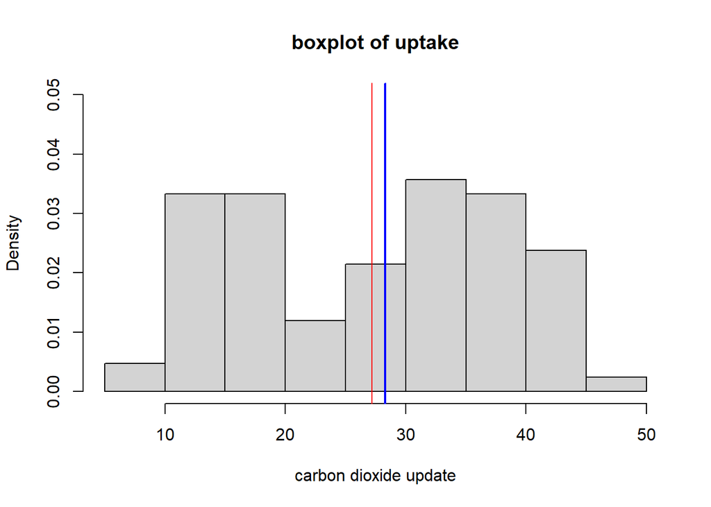

```r
hist(mydata$uptake,freq = FALSE, ylim = c(0,0.05), main="boxplot of uptake",xlab='carbon dioxide update')
abline(v=mean(mydata$uptake),col='red')
abline(v=median(mydata$uptake), col= "blue", lwd=2)
```

```r
#density histogram of sampled uptake  values

set.seed(1234)
sample_data<-mydata[sample(nrow(mydata), 30), ]
mean(sample_data$uptake)
```

```
## [1] 28.50667
```

```r
median(sample_data$uptake)
```

```
## [1] 29.5
```

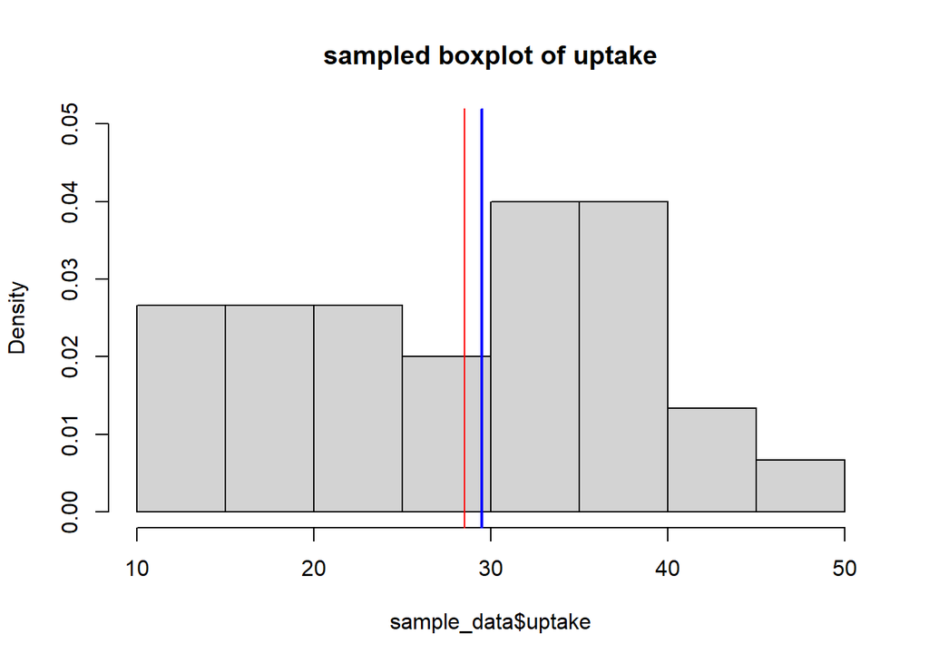

```r
hist(sample_data$uptake,freq = FALSE, ylim = c(0,0.05), main = "sampled boxplot of uptake")
abline(v=mean(sample_data$uptake),col='red')
abline(v=median(sample_data$uptake),col='blue', lwd=2)
```

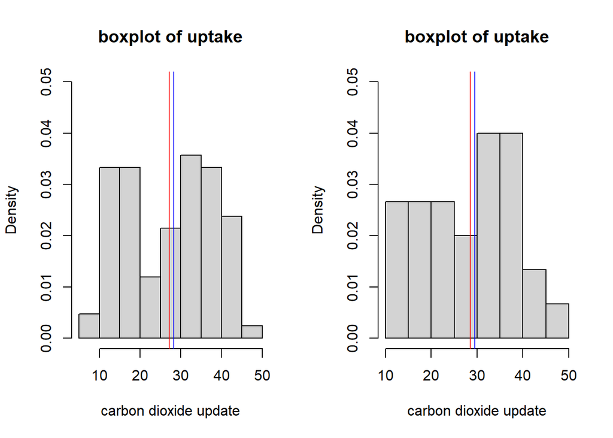

```r
#Histogram side by side?

par(mfrow = c(1,2))
hist(mydata$uptake,freq = FALSE, ylim = c(0,0.05), main="boxplot of uptake",xlab='carbon dioxide update')
abline(v=mean(mydata$uptake),col='red')
abline(v=median(mydata$uptake), col= "blue", lwd=1)
hist(sample_data$uptake, breaks = 8, freq = FALSE, ylim = c(0,0.05),main="boxplot of uptake",xlab='carbon dioxide update')
abline(v=mean(sample_data$uptake),col='red')
abline(v=median(sample_data$uptake),col='blue', lwd=1)
```

Question 2 Recall the variable letters (it is already defined in R base).